# Nonlocal Prior

Author

Yueheng Wu

Published

February 23, 2026

📄 Johnson, V. E., & Rossell, D. (2010). On the Use of Non-Local Prior Densities in Bayesian Hypothesis Tests. Journal of the Royal Statistical Society. Series B (Statistical Methodology), 72(2), 143–170. http://www.jstor.org/stable/40541581

```r
# ============================================================
# Moment-prior family for delta >= 0 with matched median = 2
# Base: half-t(df=6, scale=2.79)  (as you decided)
# Orders: d = 0,1,2,3
# Output:
#   - kappa values (median-matching)
#   - quantile table (q50/q90/q99)
#   - one plot with 4 prior curves
# ============================================================

# ---- settings
df0 <- 6
s0 <- 2.79
m_target <- 2
orders <- 0:3
probs <- c(0.5, 0.9, 0.99)

# ---- base half-t+ pdf: g(x), x>=0
g_base <- function(x, df = df0, s = s0) {
  2 * dt(x / s, df = df) / s
}

# ---- normalizing constant C_d for kappa = 1
C_d_half_t <- function(d, df = df0, s = s0) {
  if (d >= df) {
    stop("Need d < df for the moment to exist (choose df > max d).")
  }
  s^d * (df^(d / 2)) * gamma((d + 1) / 2) * gamma((df - d) / 2) / (sqrt(pi) * gamma(df / 2))
}

# ---- scaled base: g_k(x) = (1/k) g(x/k)
g_scaled <- function(x, kappa, df = df0, s = s0) {
  (1 / kappa) * g_base(x / kappa, df = df, s = s)
}

# ---- moment prior pdf with scaled base
# pi_{d,k}(x) = x^d g_k(x) / C_d(k),  where C_d(k) = k^d * C_d(1)
prior_moment <- function(x, d, kappa, df = df0, s = s0) {
  if (any(x < 0)) {
    stop("x must be >= 0")
  }
  if (d == 0) {
    return(g_scaled(x, kappa = kappa, df = df, s = s))
  }
  Ck <- (kappa^d) * C_d_half_t(d, df = df, s = s)
  x^d * g_scaled(x, kappa = kappa, df = df, s = s) / Ck
}

# ---- numeric quantile for a given prior pdf
prior_quantile <- function(pdf_fun, p, upper_start = NULL, rel.tol = 1e-8) {
  cdf <- function(q) {
    if (q <= 0) {
      return(0)
    }
    integrate(pdf_fun, lower = 0, upper = q, rel.tol = rel.tol)$value
  }
  upper <- if (is.null(upper_start)) 1 else upper_start
  while (cdf(upper) < p) {
    upper <- upper * 2
  }
  uniroot(function(q) cdf(q) - p, lower = 0, upper = upper, tol = 1e-8)$root
}

# ---- compute kappa_d so median is m_target
# scaling property: median(d,kappa) = kappa * median(d,1)
# so kappa = m_target / median(d,1)
compute_kappa <- function(d) {
  pdf_k1 <- function(x) prior_moment(x, d = d, kappa = 1)
  med1 <- prior_quantile(pdf_k1, p = 0.5, upper_start = s0)
  m_target / med1
}

# ---- kappa values
kappa <- setNames(vapply(orders, compute_kappa, numeric(1)), paste0("d", orders))

# ---- quantile table
quantile_table <- do.call(
  rbind,
  lapply(orders, function(d) {
    pdf <- function(x) prior_moment(x, d = d, kappa = kappa[paste0("d", d)])
    qs <- vapply(probs, function(p) prior_quantile(pdf, p = p, upper_start = s0), numeric(1))
    data.frame(order = paste0("d", d), q50 = qs[1], q90 = qs[2], q99 = qs[3], row.names = NULL)
  })
)
quantile_table$kappa <- unname(kappa[quantile_table$order])
```

## 1. Moment prior

In Johnson & Rossell’s definition of a moment prior, the prior density is proportional to a polynomial term that vanishes at the null value, multiplied by a base prior density. For a scalar parameter $\theta$ with null value $\theta_0$, the moment prior of order $k$ is defined as:

$$\pi_M(\theta)=\frac{(\theta-\theta_0)^{2k}}{\tau_k}\,\pi_b(\theta)$$

where
$$C_d = \int_0^\infty \delta^d g(\delta)\, d\delta = \mathbb{E}_g[\delta^d],$$

- The base prior below which makes sure the median is 2, the base prior must have the relevant finite moments, and the moment across different orders $d$ is finite.
  $$g(\delta) = t^+_{6}(0, 2.79)$$
- Choose $\kappa_d$ to match median = 2. This keeps tails comparable while still forcing $\pi_d(0)=0$ for $d\ge1$.

```r
knitr::kable(
  dplyr::mutate(
    quantile_table,
    dplyr::across(where(is.numeric), ~ round(.x, 3))
  ),
  caption = "Quantiles of the moment priors with median-matching kappa"
)
```

Quantiles of the moment priors with median-matching kappa

| order | q50 | q90 | q99 | kappa |
| --- | --- | --- | --- | --- |
| d0 | 2 | 5.416 | 10.333 | 0.999 |
| d1 | 2 | 4.351 | 8.153 | 0.518 |
| d2 | 2 | 4.222 | 8.426 | 0.348 |
| d3 | 2 | 4.483 | 10.393 | 0.246 |

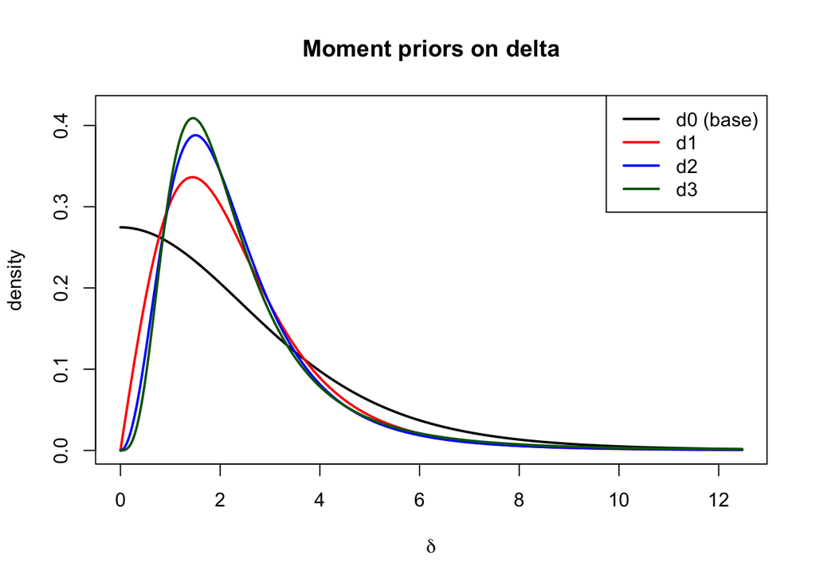

```r
cols <- c("black", "red", "blue", "darkgreen")
x_max <- max(quantile_table$q99) * 1.2

f0 <- Vectorize(function(x) prior_moment(x, d = 0, kappa = unname(kappa["d0"]), df = df0, s = s0))
f1 <- Vectorize(function(x) prior_moment(x, d = 1, kappa = unname(kappa["d1"]), df = df0, s = s0))
f2 <- Vectorize(function(x) prior_moment(x, d = 2, kappa = unname(kappa["d2"]), df = df0, s = s0))
f3 <- Vectorize(function(x) prior_moment(x, d = 3, kappa = unname(kappa["d3"]), df = df0, s = s0))

curve(
  f0,
  from = 0,
  to = x_max,
  n = 2000,
  col = cols[1],
  lwd = 2,
  xlim = c(0, x_max),
  ylim = c(0, 0.42),
  xlab = expression(delta),
  ylab = "density",
  main = "Moment priors on delta"
)
curve(f1, from = 0, to = x_max, n = 2000, add = TRUE, col = cols[2], lwd = 2)
curve(f2, from = 0, to = x_max, n = 2000, add = TRUE, col = cols[3], lwd = 2)
curve(f3, from = 0, to = x_max, n = 2000, add = TRUE, col = cols[4], lwd = 2)

legend("topright", legend = c("d0 (base)", "d1", "d2", "d3"), col = cols, lwd = 2, lty = 1)
```

## compute interval-null BF10 for delta

Testing problem:
$$H_0: \delta = 0 \quad \text{vs} \quad H_1: \delta > 0$$

Interval-null BF10:
$$\text{BF10} = \frac{P(\delta < \epsilon \mid H_1)}{P(\delta < \epsilon \mid H_0)}, \quad \epsilon > 0.$$

$$\text{BF10} = \frac{\pi_d(\delta < \epsilon)}{\pi_d(\delta < \epsilon \mid y)}, \quad \epsilon > 0.$$

How to go from formula 1 to 2??

Stan Model:

```stan
real s_eff = s_delta * kappa_delta;

for (j in 1:P) {
  // base half-t+ on delta with scale s_eff
  lprior += student_t_lpdf(delta[j] | df_delta, 0, s_eff) - student_t_lccdf(0 | df_delta, 0, s_eff);

  // multiply by delta^d  => add d*log(delta)
  if (d_order > 0)
    lprior += d_order * log(delta[j]);

  // subtract normalization: logC_base + d*log(kappa_delta)
  // Requirement: logC_base is computed for this d_order under base scale s_delta (kappa=1)
  // For d_order=0, set logC_base=0 and typically kappa_delta=1.
  lprior -= (logC_base + d_order * log(kappa_delta));
}
```

```latex
# ============================================================
# Part 1: Simulate Data with Known GP Effect
# ============================================================
set.seed(123)
N <- 50
X <- seq(-0.5, 0.5, length = N) |> matrix(ncol = 1)

# Generate data with
# (1) true delta = 3 (nonlinear effect exists)
# (2) true delta = 0.1 (no nonlinear effect)
y <- generate_gp_data(
  delta = 3,
  lambda = 0.3,
  sigma = 0.1,
  N = 50,
  x = X,
  n_samples = 1
) |>
  as.vector()
```

```latex
# Build Stan input data for a given moment-prior order d_order
# Requires objects already defined in your script:
#   df0, s0, kappa, C_d_half_t()

make_stan_data <- function(X, y, d_order) {
  X <- as.matrix(X)
  y <- as.vector(y)
  stopifnot(nrow(X) == length(y))

  if (!(paste0("d", d_order) %in% names(kappa))) {
    stop("kappa does not contain this d_order. Recompute kappa first.")
  }

  list(
    N = nrow(X),
    P = ncol(X),
    X = X,
    y = y,
    d_order = as.integer(d_order),
    kappa_delta = as.numeric(kappa[paste0("d", d_order)]),
    df_delta = as.integer(df0),
    s_delta = as.numeric(s0),
    logC_base = if (d_order == 0) 0 else log(C_d_half_t(d_order, df = df0, s = s0))
  )
}

data_d0 <- make_stan_data(X, y, 0)
data_d1 <- make_stan_data(X, y, 1)
data_d2 <- make_stan_data(X, y, 2)
data_d3 <- make_stan_data(X, y, 3)
```

```latex
fit_gp_p1 <- rstan::sampling(
  gp_add_16,
  data = data_d0,
  iter = 5000,
  warmup = 500,
  chains = 2,
  seed = 123,
  refresh = 1000,
  verbose = FALSE,
  open_progress = FALSE
)

fit_gp_p2 <- rstan::sampling(
  gp_add_16,
  data = data_d1,
  iter = 5000,
  warmup = 500,
  chains = 2,
  seed = 123,
  refresh = 1000,
  verbose = FALSE,
  open_progress = FALSE
)

fit_gp_p3 <- rstan::sampling(
  gp_add_16,
  data = data_d2,
  iter = 5000,
  warmup = 500,
  chains = 2,
  seed = 123,
  refresh = 1000,
  verbose = FALSE,
  open_progress = FALSE
)

fit_gp_p4 <- rstan::sampling(
  gp_add_16,
  data = data_d3,
  iter = 5000,
  warmup = 500,
  chains = 2,
  seed = 123,
  refresh = 1000,
  verbose = FALSE,
  open_progress = FALSE
)

fit_null <- rstan::sampling(
  gp_null,
  data = data_d3,
  iter = 5000,
  warmup = 500,
  chains = 2,
  seed = 123,
  refresh = 1000,
  verbose = FALSE,
  open_progress = FALSE
)

bridge0 <- bridgesampling::bridge_sampler(fit_null)

bridgesampling::bf(bridgesampling::bridge_sampler(fit_gp_p1), bridge0, log = TRUE)$bf
bridgesampling::bf(bridgesampling::bridge_sampler(fit_gp_p2), bridge0, log = TRUE)$bf
bridgesampling::bf(bridgesampling::bridge_sampler(fit_gp_p3), bridge0, log = TRUE)$bf
bridgesampling::bf(bridgesampling::bridge_sampler(fit_gp_p4), bridge0, log = TRUE)$bf
```

```latex
# Compute interval-null BF tables for four rstan fits (d=0,1,2,3)
# Uses: rstan::extract(fit)$delta

get_delta_draws_rstan <- function(fit) {
  delta <- rstan::extract(fit)$delta
  as.numeric(delta) # flatten iterations x P
}

run_bf_for_4fits_rstan <- function(fits, orders = 0:3, eps = c(0.1, 0.3, 0.5, 0.7), d_sd = c(2, 4, 6)) {
  stopifnot(length(fits) == length(orders))

  do.call(
    rbind,
    lapply(seq_along(fits), function(i) {
      delta_draws <- get_delta_draws_rstan(fits[[i]])
      tbl <- bf10_interval_null_delta_moment(
        delta_draws = delta_draws,
        d_order = orders[i],
        eps = eps,
        d = d_sd,
        return_log = TRUE
      )
      tbl$order <- paste0("d", orders[i])
      tbl[, c("order", "epsilon", "tag", "prior0", "post0", "log_bf10")]
    })
  )
}

fits <- list(fit_gp_p1, fit_gp_p2, fit_gp_p3, fit_gp_p4) # must correspond to d=0..3
bf_table <- run_bf_for_4fits_rstan(fits, orders = 0:3)
bf_table
```

```latex
# Compute logBF10 curves on an epsilon grid using bf10_interval_null_delta_moment()
# (which uses logspline for post0), then plot one line per d.

get_delta_draws <- function(fit) as.numeric(rstan::extract(fit)$delta)

plot_logbf10_grid_logspline <- function(
  fits, # list of 4 rstan fits in order d=0,1,2,3
  orders = 0:3,
  eps_grid = seq(0.01, 1, by = 0.01),
  cols = c("black", "red", "blue", "darkgreen")
) {
  stopifnot(length(fits) == length(orders))

  logbf_mat <- matrix(NA_real_, nrow = length(eps_grid), ncol = length(orders))
  colnames(logbf_mat) <- paste0("d", orders)

  for (i in seq_along(orders)) {
    d <- orders[i]
    delta_draws <- get_delta_draws(fits[[i]])

    # Use YOUR logspline-based BF function at each grid point
    tab <- bf10_interval_null_delta_moment(
      delta_draws = delta_draws,
      d_order = d,
      eps = eps_grid,
      d = NULL, # no sd-based eps here
      return_log = TRUE
    )

    # Ensure order matches eps_grid
    tab <- tab[match(eps_grid, tab$epsilon), ]
    logbf_mat[, i] <- tab$log_bf10
  }

  matplot(
    eps_grid,
    logbf_mat,
    type = "l",
    lty = 1,
    lwd = 2,
    col = cols,
    xlab = expression(epsilon),
    ylab = expression(log(BF[10]))
  )
  abline(h = 0, lty = 2)
  legend("bottomright", legend = colnames(logbf_mat), col = cols, lty = 1, lwd = 2)

  invisible(list(eps = eps_grid, logbf = logbf_mat))
}

fits <- list(fit_gp_p1, fit_gp_p2, fit_gp_p3, fit_gp_p4)
res <- plot_logbf10_grid_logspline(fits, orders = 0:3, eps_grid = seq(0.01, 1, by = 0.01))
```

```latex
plot_logbf10_grid_logspline(fits, orders = 0:3, eps_grid = seq(0.005, 0.4, by = 0.002))
```